# R Notebook

# Equivalence testing for the SIP paper

The goal is to select genes that are equivalent or not-expressed in one mating type and significant DE (with the same cutoff value) in the other mating type.

A more elegant way to perform TOST would be to use the Wald test that Koen and Lieven have been developing, but since it is still being worked on we will use the LRT of EdgeR for the SIP paper.

For MT+, only the first 3 timepoints are checked if they are DE

The model formula of the SIP RNA-seq experiment with 3 timepoints is:
$$log(Y_{i}) = \beta_{c0} + \beta_{c15}X_{c15} + \beta_{t15}X_{t15} + \beta_{c1}X_{c1} + \beta_{c1}X_{c1} + \beta_{c3}X_{c3} + \beta_{c3}X_{c3}$$

# Equivalence analysis in MT-

### loading libraries and data

```r
# function that returns a data frame of equivalence p-values (unadjusted!) for the three contrasts at a given FC cutoff
equivalence_test3 <- function(deltalog){
  for (contrast_number in c(1,2,3)){
    new_design <- contrastAsCoef(design, contrast = L[,contrast_number], first = TRUE)
    new_design <- data.frame(new_design$design)

    y <- d

    # get original offsets (existing offset is used to correct for library size and RNA composition effect)
    orig.offs <- getOffset(y)
    # add log(cutoff value for FC) to the offset of the samples we want to compare: this will make that we don't test for Ha =!= 0, but Ha =!= FC_value (two sided).
    y$offset <- orig.offs + (deltalog)*new_design$C1
    # refit model with adjusted offset
    fit.up <- glmFit(y, new_design)
    # LRT
    lrt.up <- glmLRT(fit.up, coef = 1)
    # other side
    y$offset <- orig.offs - (deltalog)*new_design$C1
    # refit model with adjusted offset
    fit.down <- glmFit(y, new_design)
    # LRT
    lrt.down <- glmLRT(fit.down, coef = 1)
    # tests were two-sided. convert to one-sided.
    p.up <- ifelse(lrt.up$table$logFC < 0, lrt.up$table$PValue/2, 1)
    p.down <- ifelse(lrt.down$table$logFC > 0, lrt.down$table$PValue/2, 1)
    # get TOST p-value.
    p.tost2 <- pmax(p.up, p.down)

    assign(paste0("genes_", contrast_number), p.tost2)
  }
  genes123 <- data.frame(rownames(d),genes_1, genes_2, genes_3)
  colnames(genes123) <- c("gene_ID", "p_15", "p_1", "p_3")


  # first apply FWER (Holm) to the contrasts
  eq3_FWER <- data.frame(stringsAsFactors = F)
  for (row in 1:nrow(genes123)){                     # this should be possible with apply but I couldn't let it work :(
    eq3_FWER <- rbind(eq3_FWER, p.adjust(genes123[row,2:4], method = "holm"))
  }

  rownames(eq3_FWER) <- genes123$gene_ID
  colnames(eq3_FWER) <- colnames(eq3_FWER)[2:4]

  # select least significant contrast (t15,t1,t3)
  max_eq3_FWER <- apply(eq3_FWER,1,max)

  # FDR correction on least significant contrast
  max_eq3_FWER_FDR <- p.adjust(max_eq3_FWER, "fdr")

  sum(max_eq3_FWER_FDR <= 0.05)   # number of significant genes in all three timepoints


  return(names(max_eq3_FWER_FDR[max_eq3_FWER_FDR <= 0.05]))
}

## Run the test

delta <- 3
deltalog <- log(delta)
deltalog2 <- log2(delta)

equiv3_LRT <- equivalence_test3(deltalog)
```

# Check results

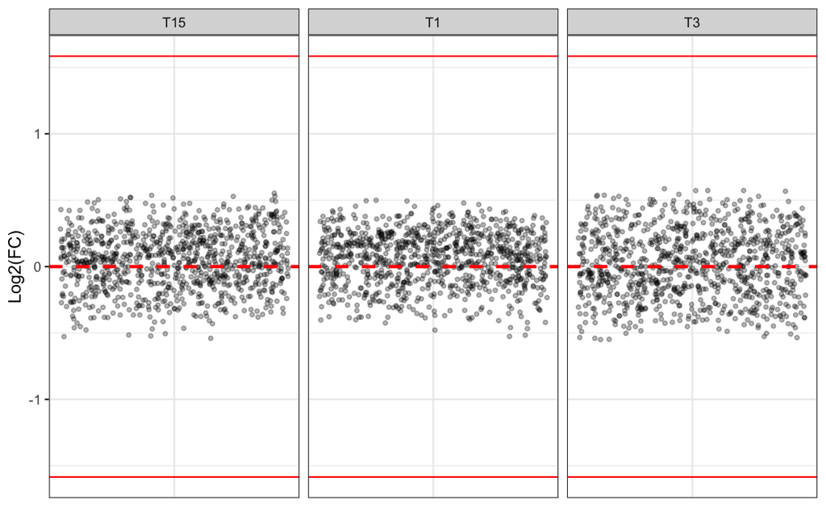

```r
log2FcMatrix_min <-  as.data.frame(read.delim(paste0(dir,"/DE_matrices/log2_Fold_Changes_MT-_Moeys.txt"), header = TRUE, sep = "", row.names = 1, stringsAsFactors = FALSE))

log2FC <- log2FcMatrix_min[rownames(log2FcMatrix_min) %in% equiv3_LRT,]

log2FC <- data.frame( c(log2FC$t15, log2FC$t1, log2FC$t3), c(rep("T15", nrow(log2FC)), rep("T1", nrow(log2FC)), rep("T3", nrow(log2FC))))
colnames(log2FC) <- c("log2FC", "tp")
log2FC$tp <- factor(log2FC$tp, levels = unique(log2FC$tp))

ggplot(data = log2FC) +
    geom_jitter(aes(x = 1, y = log2FC), size = 1, alpha = 0.30) +
    geom_hline(aes(yintercept = 0), size= 1, linetype = "dashed", color = "red") +
  geom_hline(aes(yintercept = deltalog2), size = 0.5, color = "red")+
  geom_hline(aes(yintercept = -deltalog2), size = 0.5, color = "red") +
   xlab("") +
   ylab("Log2(FC)") +
  theme(axis.title.x=element_blank(), axis.text.x=element_blank(), axis.ticks.x=element_blank()) +
 facet_grid(~ tp, scales='free', space = "free_x") +
  theme_bw() +
  theme(axis.title.x=element_blank(),
        axis.text.x=element_blank(),
        axis.ticks.x=element_blank()) +
  scale_x_continuous(breaks = c(1)) +
  scale_y_continuous(breaks = c(-1,0,1))
```

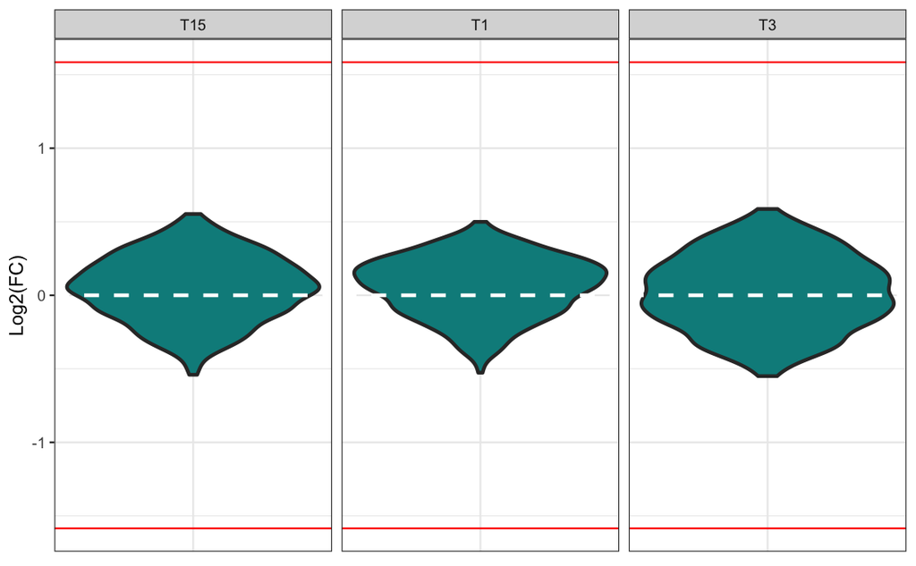

```r
ggplot(data = log2FC) +
    geom_violin(aes(x = 1, y = log2FC), size = 1, fill = "cyan4") +
    geom_hline(aes(yintercept = 0), size= 1, linetype = "dashed", color = "white") +
  geom_hline(aes(yintercept = deltalog2), size = 0.5, color = "red")+
  geom_hline(aes(yintercept = -deltalog2), size = 0.5, color = "red") +
   xlab("") +
   ylab("Log2(FC)") +
  theme(axis.title.x=element_blank(), axis.text.x=element_blank(), axis.ticks.x=element_blank()) +
 facet_grid(~ tp, scales='free', space = "free_x") +
  theme_bw()+
  theme(axis.title.x=element_blank(),
        axis.text.x=element_blank(),
        axis.ticks.x=element_blank()) +
  scale_x_continuous(breaks = c(1)) +
  scale_y_continuous(breaks = c(-1,0,1))
```

### Exporting “non-responsive” genes to take to the other mating type

Non-responsive genes are: (1) “low expression genes” (filtered) (2) genes equivalent at all three tp for FC cutoff x

```r
non_responsive <- data.frame(c(low_expression, equiv3_LRT), c(rep("filtered", length(low_expression)), rep("equivalent", length(equiv3_LRT))))
colnames(non_responsive) <- c("gene_ID","type")
```

# Analysis of DE in MT+

Now we switch to MT+ and look which of the genes in ‘non-responsive’ are significantly DE (>< FC cutoff).

### filtering (1) non-responsive genes MT+, then (2) cpm >1

```r
### COMMENTED OUT FOR INTERSECTION ANALYSIS
#(1) filter non-responsive genes
# d <- d[rownames(d$counts) %in% non_responsive$gene_ID,]
# nrow(d$counts) # number of genes after filtering of MT+ non-responsive genes

#(2) filter on cpm
keep <- rowSums(cpm(d)>1)>=3
d <- d[keep,]
nrow(d$counts) # number of genes after filtering on cpm
```

```
[1] 26956
```

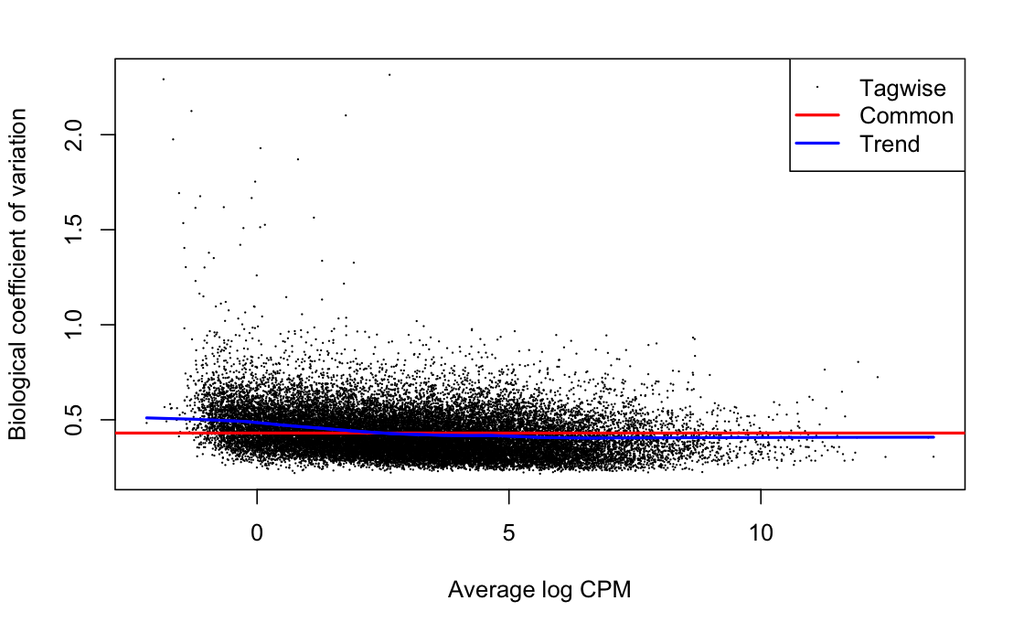

```r
# normalization
d$samples$lib.size <- colSums(d$counts)
d <- calcNormFactors(d)

# Fit normal model without reparametrization
d <- estimateDisp(d,design)
plotBCV(d)
```

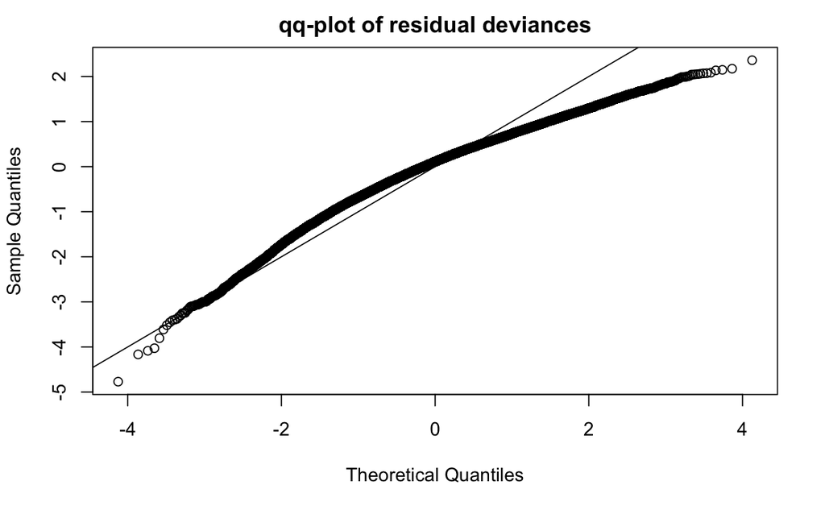

```r
# fit model (based on the design factors and negative binomial dispersions, this will fit the negative binomial model through every level)
fit <- glmFit(d,design)

## check if the residuals follow a negative binomial distribution (Q-Q plot)
gofStat <- gof(fit,plot=TRUE)
```

```r
## contrast matrix  (contrasts are used to determine which factors from the design matrix to compare, i.e. is the difference in coefficient significantly different from zero instead of 'is the coefficient different from zero', in this case compare treat vs control for every timepoint)

 ### Contrast matrix for only t15,t1 and t3
L=matrix(0,nrow=ncol(coef(fit)),ncol=3)
rownames(L)=colnames(coef(fit))
colnames(L)=c("t15","t1","t3")
L[c(7,2)+1,1] <- c(1,-1) #t15
L[c(6,1)+1,2] <- c(1,-1) #t1
L[c(8,3)+1,3] <- c(1,-1) #t3
```

### GLMtreat in MT+

Stagewise testing with P-value aggregation with the Sidak method

```r
library(aggregation)

logFcMatrix <-  as.data.frame(read.delim(paste0(dir,"/DE_matrices/log2_Fold_Changes_MT+.txt"), header = TRUE, sep = "", row.names = 1, stringsAsFactors = FALSE))

tr15 <- glmTreat(fit, contrast = as.data.frame(L)$t15, lfc= deltalog2)
tr1 <- glmTreat(fit, contrast = as.data.frame(L)$t1, lfc= deltalog2)
tr3 <- glmTreat(fit, contrast = as.data.frame(L)$t3, lfc= deltalog2)

# Aggregate p-values
all_p_tr <- data.frame(tr15$table$PValue, tr1$table$PValue, tr3$table$PValue)
colnames(all_p_tr) <- c("t15", "t1", "t3")
rownames(all_p_tr) <- rownames(tr15)

p_screening_tr <- apply(all_p_tr, 1, function(x) sidak(x))
```

[output not shown]

```r
names(p_screening_tr) <- rownames(tr15)
p_confirmation_tr <- as.matrix(all_p_tr)

stageRobj_tr <- stageR(pConfirmation = p_confirmation_tr, pScreen = p_screening_tr)
stageRobj2_tr <- stageWiseAdjustment(object = stageRobj_tr, method = "holm", alpha = 0.05)

res_tr <- as.data.frame(getResults(stageRobj2_tr))
```

```
The returned adjusted p-values are based on a stage-wise testing approach and are only valid for the provided target OFDR level of 5%. If a different target OFDR level is of interest,the entire adjustment should be re-run.
```

```r
sign_ML <- res_tr[res_tr$padjScreen == 1,]

names <- rownames(res_tr[res_tr$padjScreen == 1,])

table(non_responsive$type[non_responsive$gene_ID %in% names])
```

```
equivalent   filtered
         0         10
```

```r
logFC_ML <- logFcMatrix[rownames(logFcMatrix) %in% names,]

res <- res_tr[res_tr$padjScreen == 1, 2:4]
logFC <- logFC_ML[,1:3]

dir <- logFC*res

upDown <- function(value){
if (value > 0) {
  return("up")
}
if (value == 0) {
  return("")
}
else {
  return("down")
}
}

upD15 <- sapply(dir$t15, function(x) upDown(x))
upD1 <- sapply(dir$t1, function(x) upDown(x))
upD3 <- sapply(dir$t3, function(x) upDown(x))

out <- data.frame(names, upD15, upD1, upD3)
out$upDall <- paste0(out$upD15, out$upD1, out$upD3 )

out$upDall[out$upDall== "upup"] <- "up"
out$upDall[out$upDall== "upupup"] <- "up"

out$upDall[out$upDall== "downdown"] <- "down"
out$upDall[out$upDall== "downdowndown"] <- "down"

out
```

| names | upD15 | upD1 | upD3 | upDall |
| --- | --- | --- | --- | --- |
| Sro1010_g230870 |  |  | up | up |
| Sro1053_g235830 |  |  | up | up |
| Sro106_g053660 |  |  | up | up |
| Sro1096_g240760 |  |  | up | up |
| Sro1124_g243820 |  |  | up | up |
| Sro1148_g246500 |  | up | up | up |
| Sro1186_g250410 | up |  |  | up |
| Sro1205_g252310 |  |  | up | up |
| Sro1251_g256170 |  |  | up | up |
| Sro1252_g256250 |  |  | up | up |

[output cut: 47 more lines]

```r
NA
```

> As all “non-responsive” genes belong to the “filtered” (non expressed) class, we cannot plot their FC. Alternatively we could plot the filtered genes as having a log2FC of “0” (see Figure 4 of the paper)